# Rethinking Traditional Values

Analyzing How Messages of Climate Change Affect Family Planning Among Millennials and Generation Z

Laura Gattis, Sam Lorenzo, Megan Denneny, Emmanuel Maduneme

2022-12-07

# Abstract

Climate change is perceived as a significant threat, especially among younger demographics. Millennials (born 1981-1996) are the most adamant about reversing the issue, with 71% stating it is a top priority to protect and sustain the planet for future generations. Generation Z adults, those over 18 (born 1997-2004), also share similar sentiments. According to prior studies, 1-in-4 U.S. adults under the age of 45 revealed that climate change risks motivate their decision to not have children. This study is the initial phase in a series of research. We have collected more than 150 surveys and began interviewing Millennials and Generation Z adults in Ghana. Both methods explore how participants view climate change messages and how this influences family planning. Our next step is to duplicate this study in the U.S. and eventually other countries to provide a comprehensive, comparative analysis of climate change and family planning perceptions across the globe.

# Introduction

Climate change continues to be perceived as a significant risk among Americans, especially among younger demographics. Millennials, in particular, those born between 1981 and 1996, were found to be the group most adamant about prioritizing the issue of climate change, with 71 percent of Millennials indicating climate change to be the most important issue to address in order to protect and sustain the planet for future generations (Funk, 2021). According to a 2020 poll by Morning Consult, one-in-four adults under the age of 45 indicated that climate change plays a role (either major or minor) in their decision to not have children (Jenkins, 2020). A prior survey also measured the various reasons why young adults are choosing to have fewer than their ideal number of children, with 37 percent of respondents expressing a concern about global instability and 33 percent specifying the burden of climate change as key motives (Miller, 2018)

We hypothesize that the way in which media messages about climate change are framed and interpreted negatively impacts Millennial and Generation Z perceptions about having children.

## Specific Aims/Study Objectives

This analysis intends to answer the following research question: What effect do messages about climate change have on Millennials and Generation Z and their desire to have children?

# Methods, Materials, and Analysis

We used `R programming` (R Core Team, 2022) for analysis with the following packages: `janitor` (Firke, 2021), `psych` (Revelle, 2022), `skimr` (Waring et al., 2022), `here` (Müller, 2020), `knitr` (Xie, 2014), `rio` (Chan et al., 2021), `readxl` (Wickham & Bryan, 2022), `DT` (Xie et al., 2022) and `tidyverse` (Wickham et al., 2019). After loading our data set **css_ghana**, we proceeded to use different functions like `filter()`, `mutate()`, `pivot_longer`, `pivot_wider`, `group_by`, and `select()` to tidy the data.

## Data Preparation Script Plan:

We are utilizing the data collected to quantitatively determine if there are any correlations between views amongst demographics and to see if responses tend to skew towards specific perceptions (e.g., high fear of climate change, low desire to have children). Our plan is to use our data to better visualize participant responses and categorize information into a variety of sets. We are employing a randomizer tool to skew the responses we received.

These are some descriptive information about the data.

|  | Gender | Age Generation | Climate Change Concern | Climate Change Priority | Media Climate Change Message Efficacy | Desire For Children |
| --- | --- | --- | --- | --- | --- | --- |
| 1 | Male | Millennials | 1 | 3 | 3 | 3 |
| 2 | Male | Gen_Z | 1 | 3 | 3 | 3 |
| 3 | Female | Millennials | 1 | 3 | 3 | 3 |
| 4 | Female | Gen_Z | 1 | 3 | 3 | 3 |
| 5 | Male | Millennials | 4 | 4 | 5 | 2 |
| 6 | Male | Gen_Z | 4 | 4 | 5 | 2 |
| 7 | Female | Millennials | 4 | 4 | 5 | 2 |
| 8 | Female | Gen_Z | 4 | 4 | 5 | 2 |
| 9 | Male | Millennials | 5 | 4 | 3 | 4 |
| 10 | Male | Gen_Z | 5 | 4 | 3 | 4 |

[output cut: 342 more lines]

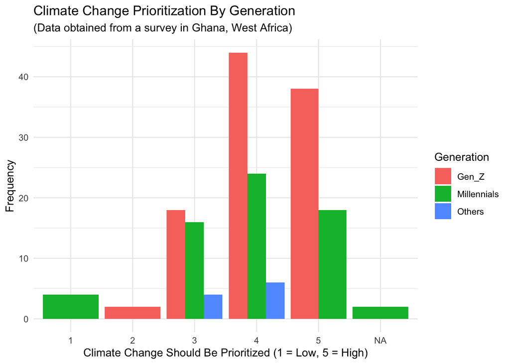

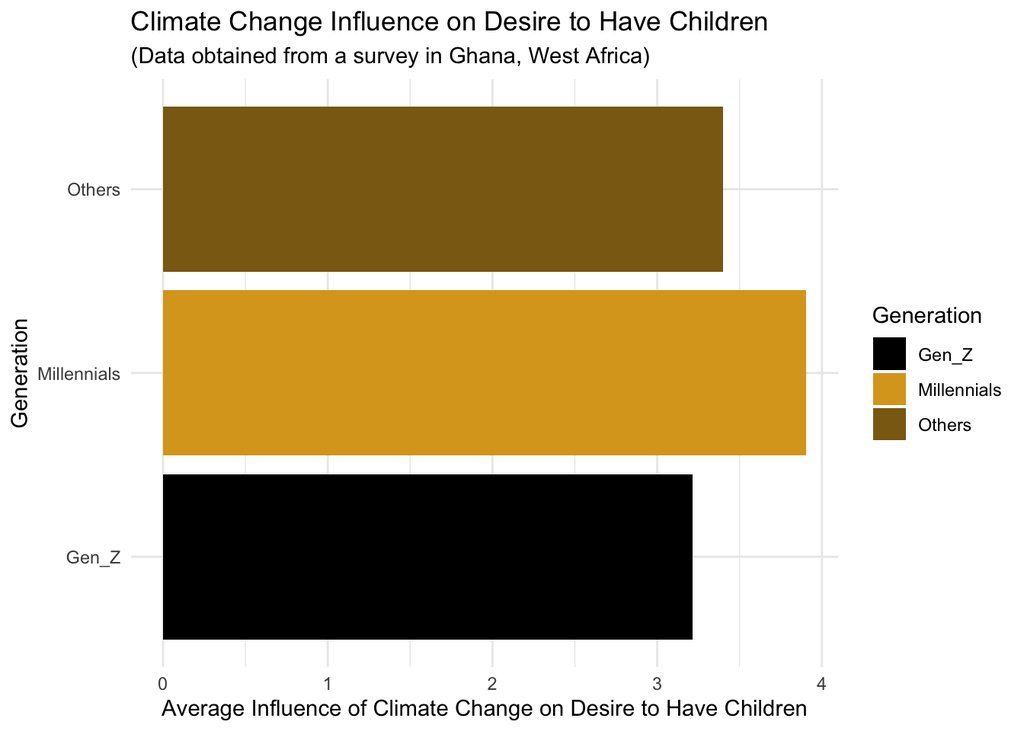

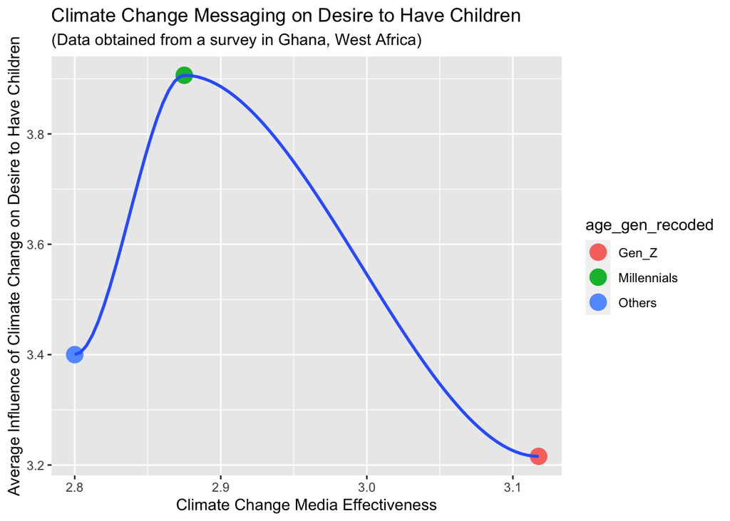

# Initial Findings and Results

Based on our preliminary analysis, Ghanaian participants who indicated that they were “extremely concerned” about climate change also tended to state that they have experienced some level of negative emotions when exposed to climate change messages, as well as mixed responses about their desire to have children due to climate change risks. Once we complete our analyses, we expect to uncover a more wholistic narrative of the Ghanaian perspective, which may include external influences such as cultural and societal values.

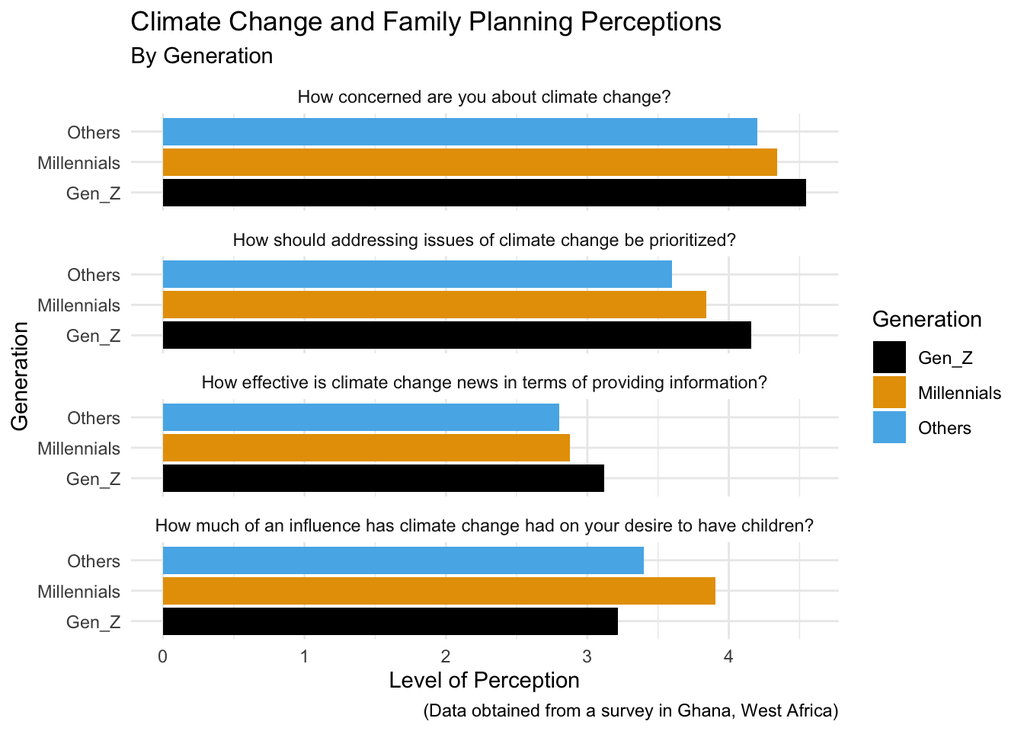

# Findings

This graph demonstrates climate change and family perceptions by generation broken down by four key questions asked in interviews. 1.) How concerned are you about climate change? 2.) How should addressing issues of climate change be prioritized? 3.) How effective is climate change news in terms of providing information? 4.) How much of an influence has climate change had on your desire to have children? One key insight to highlight from the graph is that although Generation Z is the most concerned about climate change and addresses how these concerns should be prioritized, the data also shows that Generation Z is less likely to be influenced by climate change in their desire to have children.

# Discussion and Broader impact

Overall, our initial findings are impactful to better understanding the correlation between climate change and the lessened desire to have children amongst Millennials and Generation Z. The survey data collected in Ghana in 2022 will be helpful to compare to the U.S. and other countries in future data collection, all of which will come together to create a larger snapshot of this topic. Early findings suggest that climate change may have an impact on reproduction decision-making which can be insightful in locations like the U.S. where recent political and economical factors may also contribute. With this data, we can better infer how other countries may respond to similar structures and challenges as well as contribute solutions to current problems.

# References

Chan, C., Chan, G. C., Leeper, T. J., & Becker, J. (2021). *Rio: A swiss-army knife for data file i/o*.

Firke, S. (2021). *Janitor: Simple tools for examining and cleaning dirty data*. https://CRAN.R-project.org/package=janitor

Funk, C. (2021). Key findings: How americans’ attitudes about climate change differ by generation, party and other factors. *Washington, DC: Pew Research Center, Available Online: Https://Www. Pewresearch. Org/Fact-Tank/2021/05/26/Key-Findings-How-Americansattitudes-about-Climate-Change-Differ-by-Generation-Party-and-Other-Factors/(Accessed on 14 July 2021)*.

Jenkins, L. M. (2020). *Americans are having fewer babies. They told us why*. Morning Consult. https://morningconsult.com/2020/09/28/adults-children-climate-change-polling/

Miller, C. C. (2018). *Americans are having fewer babies. They told us why*. New York Times. https://www.nytimes.com/2018/07/05/upshot/americans-are-having-fewer-babies-they-told-us-why.html

Müller, K. (2020). *Here: A simpler way to find your files*. https://CRAN.R-project.org/package=here

R Core Team. (2022). *R: A language and environment for statistical computing*. R Foundation for Statistical Computing. https://www.R-project.org/

Revelle, W. (2022). *Psych: Procedures for psychological, psychometric, and personality research*. Northwestern University. https://CRAN.R-project.org/package=psych

Waring, E., Quinn, M., McNamara, A., Arino de la Rubia, E., Zhu, H., & Ellis, S. (2022). *Skimr: Compact and flexible summaries of data*. https://CRAN.R-project.org/package=skimr

Wickham, H., Averick, M., Bryan, J., Chang, W., McGowan, L. D., François, R., Grolemund, G., Hayes, A., Henry, L., Hester, J., Kuhn, M., Pedersen, T. L., Miller, E., Bache, S. M., Müller, K., Ooms, J., Robinson, D., Seidel, D. P., Spinu, V., … Yutani, H. (2019). Welcome to the tidyverse. *Journal of Open Source Software*, *4*(43), 1686. https://doi.org/10.21105/joss.01686

Wickham, H., & Bryan, J. (2022). *Readxl: Read excel files*. https://CRAN.R-project.org/package=readxl

Xie, Y. (2014). Knitr: A comprehensive tool for reproducible research in R. In V. Stodden, F. Leisch, & R. D. Peng (Eds.), *Implementing reproducible computational research*. Chapman; Hall/CRC. http://www.crcpress.com/product/isbn/9781466561595

Xie, Y., Cheng, J., & Tan, X. (2022). *DT: A wrapper of the JavaScript library ’DataTables’*. https://CRAN.R-project.org/package=DT